# Code Sample

Joe Mason

1/11/2021

## R Packages

If you do not have the below packages already installed, uncomment the lines and run them to install.

```r
# install.packages("tidyverse")
# install.packages("skimr")
# install.packages("ggcorrplot")
# install.packages("ggridges")
# install.packages("cowplot")
# install.packages("RColorBrewer")

library(tidyverse)
library(skimr)
library(ggcorrplot)
library(ggridges)
library(cowplot)
library(RColorBrewer)
library(car)
```

## Datasets

The datasets contain data from the WHO World Health Statistics 2020 Report, downloaded from Kaggle:

https://www.kaggle.com/utkarshxy/who-worldhealth-statistics-2020-complete

The last dataset (whoRegionCodes) was handmade by myself, created using information available on the WHO website:

https://www.who.int/about/who-we-are/regional-offices

```r
# Import the needed .csv datasets using tidyverse::read_csv()

# Life expectancy at birth by sex/country
lifeExp <- read_csv("data/lifeExpectancyAtBirth.csv")

# Medical doctors per 10000 population
docPer10k <- read_csv("data/medicalDoctors.csv")

# Nursing and Midwife personnel per 10000 population
nurseMidwifePer10k <- read_csv("data/nursingAndMidwife.csv")

# Dentists per 10000 population
dentistPer10k <- read_csv("data/Dentists.csv")

# Pharmacists per 10000 population
pharmacistPer10k <- read_csv("data/Pharmacists.csv")

# UHC index of service Coverage (SCI)
uhcCoverage <- read_csv("data/uhcCoverage.csv")

# I handmade this .csv file myself from the information at https://www.who.int/about/who-we-are/regional-offices
whoRegionCodes <- read_csv('data/whoRegionCodes.csv')
```

## Data Wrangling/Cleaning

This section is focused on looking at what data is available, specifically what years the health data was recorded by the WHO. The WHO does not track metrics yearly for each country, so there are often several year gaps between available data. Therefore, it’s important to have an understanding of what data is available between the datasets.

#### Life expectancy at birth by sex/country

```r
# Create a dataset to see when was the last year there is life expectancy data by country
lifeExpLatestYear <- lifeExp %>%
  group_by(Location) %>%
  filter(Dim1 == "Both sexes") %>%
  summarize(latestYear = max(Period))

# Check to see what the latest years are
lifeExpLatestYear %>%
  count(latestYear)
```

```
## # A tibble: 2 x 2
##   latestYear     n
##        <dbl> <int>
## 1       2010     1
## 2       2019   183
```

```r
# Investigate the one country that doesn't have 2019 data
lifeExpLatestYear %>%
  filter(latestYear == 2010)
```

```
## # A tibble: 1 x 2
##   Location           latestYear
##   <chr>                   <dbl>
## 1 Sudan (until 2011)       2010
```

```r
# Sudan is contained within 2 values, "Sudan" and "Sudan (until 2011)"

# Other datasets do not have 2019 data, so will have to find a common latest year
lifeExp %>%
  group_by(Location) %>%
  filter(Dim1 == "Both sexes") %>%
  ungroup() %>%
  count(Period)
```

[output not shown]

```r
# Life Expectancy was recorded in 2000, 2010, 2015, and 2019

# Create a dataset that will only contain data from 2015 (for overlap with data from other datasets)
# This renames the Life Expectancy (First Tooltip) and Sex (Dim1) columns; also removes the Indicator column
# This will also remove "Sudan (until 2011)" but retain "Sudan"
lifeExpFinal <- lifeExp %>%
  filter(Period == 2015) %>%
  mutate(LifeExp = `First Tooltip`,
         Sex = Dim1) %>%
  select(-c(Indicator, `First Tooltip`, Dim1))
```

#### Doctors per 10k population

```r
# Check how many countries have data by the latest year it is available
docPer10k %>%
  group_by(Location) %>%
  summarize(latestYear = max(Period)) %>%
  count(latestYear) %>%
  arrange(desc(.))
```

```
## # A tibble: 12 x 2
##    latestYear     n
##         <dbl> <int>
##  1       2018    61
##  2       2017    53
##  3       2016    32
##  4       2015    17
##  5       2014    18
##  6       2013     2
##  7       2012     1
##  8       2011     4
##  9       2010     2
## 10       2009     1
## 11       2008     2
## 12       2001     1
```

```r
# 2018 is the latest year there is data for this, fall back on 2015 for overlap with life exp data

# Check how many countries are captured by data in 2015 (to match with life expectancy data)
docPer10k %>%
  group_by(Location) %>%
  filter(Period == 2015) %>%
  nrow()
```

```
## [1] 105
```

```r
# Create a dataset for Doctors per 10000 population in 2015 by country
# This renames the DocPer10k (First Tooltip) column; also removes the Indicator column
docPer10kFinal <- docPer10k %>%
  group_by(Location) %>%
  filter(Period == 2015) %>%
  mutate(DocPer10k = `First Tooltip`) %>%
  select(-c(Indicator, `First Tooltip`))
```

#### Nurses and Midwives per 10k population

```r
# Check how many countries have data by the latest year it is available
nurseMidwifePer10k %>%
  group_by(Location) %>%
  summarize(latestYear = max(Period)) %>%
  count(latestYear) %>%
  arrange(desc(.))
```

```
## # A tibble: 7 x 2
##   latestYear     n
##        <dbl> <int>
## 1       2018   118
## 2       2017    42
## 3       2016    13
## 4       2015     9
## 5       2014    10
## 6       2013     1
## 7       2008     1
```

```r
# 2018 is the latest year there is data for this, fall back on 2015 for overlap with life exp data

# Check how many countries are captured by data in 2015 (to match with life expectancy data)
nurseMidwifePer10k %>%
  group_by(Location) %>%
  filter(Period == 2015) %>%
  nrow()
```

```
## [1] 133
```

```r
# Create a dataset for Nurses and Midwives per 10000 population in 2015 by country
# This renames the NurseMidwifePer10k (First Tooltip) column; also removes the Indicator column
nurseMidwifePer10kFinal <- nurseMidwifePer10k %>%
  group_by(Location) %>%
  filter(Period == 2015) %>%
  mutate(NurseMidwifePer10k = `First Tooltip`) %>%
  select(-c(Indicator, `First Tooltip`))
```

#### Dentists per 10k population

```r
# Check how many countries have data by the latest year it is available
dentistPer10k %>%
  group_by(Location) %>%
  summarize(latestYear = max(Period)) %>%
  count(latestYear) %>%
  arrange(desc(.))
```

```
## # A tibble: 15 x 2
##    latestYear     n
##         <dbl> <int>
##  1       2019    32
##  2       2018    54
##  3       2017    36
##  4       2016    23
##  5       2015    15
##  6       2014    13
##  7       2013     2
##  8       2011     1
##  9       2010     1
## 10       2009     1
## 11       2008     5
## 12       2006     1
## 13       2004     5
## 14       2003     1
## 15       2001     1
```

```r
# 2019 is the latest year there is data for this, fall back on 2015 for overlap with life exp data

# Check how many countries are captured by data in 2015 (to match with life expectancy data)
dentistPer10k %>%
  group_by(Location) %>%
  filter(Period == 2015) %>%
  nrow()
```

```
## [1] 87
```

```r
# Create a dataset for Dentists per 10000 population in 2015 by country
# This renames the DentistPer10k (First Tooltip) column; also removes the Indicator column
dentistPer10kFinal <- dentistPer10k %>%
  group_by(Location) %>%
  filter(Period == 2015) %>%
  mutate(DentistPer10k = `First Tooltip`) %>%
  select(-c(Indicator, `First Tooltip`))
```

#### Pharmacists per 10k population

```r
# Check how many countries have data by the latest year it is available
pharmacistPer10k %>%
  group_by(Location) %>%
  summarize(latestYear = max(Period)) %>%
  count(latestYear) %>%
  arrange(desc(.))
```

```
## # A tibble: 18 x 2
##    latestYear     n
##         <dbl> <int>
##  1       2018    51
##  2       2017    38
##  3       2016    28
##  4       2015    18
##  5       2014    17
##  6       2013     3
##  7       2012     5
##  8       2011     3
##  9       2010     4
## 10       2009     1
## 11       2008     2
## 12       2007     1
## 13       2005     1
## 14       2004     7
## 15       2003     2
## 16       2001     1
## 17       2000     2
## 18       1999     1
```

```r
# 2018 is the latest year there is data for this, fall back on 2015 for overlap with life exp data

# Check how many countries are captured by data in 2015 (to match with life expectancy data)
pharmacistPer10k %>%
  group_by(Location) %>%
  filter(Period == 2015) %>%
  nrow()
```

```
## [1] 81
```

```r
# Create a dataset for Pharmacists per 10000 population in 2015 by country
# This renames the PharmacistPer10k (First Tooltip) column; also removes the Indicator column
pharmacistPer10kFinal <- pharmacistPer10k %>%
  group_by(Location) %>%
  filter(Period == 2015) %>%
  mutate(PharmacistPer10k = `First Tooltip`) %>%
  select(-c(Indicator, `First Tooltip`))
```

#### UHC index of service Coverage (SCI)

```r
# Check how many countries have data by the latest year it is available
uhcCoverage %>%
  group_by(Location) %>%
  summarize(latestYear = max(Period)) %>%
  count(latestYear) %>%
  arrange(desc(.))
```

```
## # A tibble: 1 x 2
##   latestYear     n
##        <dbl> <int>
## 1       2017   183
```

```r
# 2017 is the latest year there is data for this, fall back on 2015 for overlap with life exp data

# Check how many countries are captured by data in 2015 (to match with life expectancy data)
uhcCoverage %>%
  group_by(Location) %>%
  filter(Period == 2015) %>%
  nrow()
```

```
## [1] 183
```

```r
# Create a dataset for UHC index of service Coverage (SCI) in 2015 by country
# This renames the UhcCoverage (First Tooltip) column; also removes the Indicator column
uhcCoverageFinal <- uhcCoverage %>%
  group_by(Location) %>%
  filter(Period == 2015) %>%
  mutate(UhcCoverage = `First Tooltip`) %>%
  select(-c(Indicator, `First Tooltip`))
```

#### WHO Region Codes

```r
# Remove empty columns from the dataset
whoRegionCodesFinal <- whoRegionCodes %>%
  select(c(Country, Region))
```

## Data Joining

The 7 datasets are joined together and the missing data is dropped from the dataframe.

```r
# Join the datasets together
worldHealthStatTemp <- lifeExpFinal %>%
  left_join(whoRegionCodesFinal, by = c('Location' = 'Country')) %>%
  left_join(docPer10kFinal, by = c('Location', 'Period')) %>%
  left_join(nurseMidwifePer10kFinal, by = c('Location', 'Period')) %>%
  left_join(dentistPer10kFinal, by = c('Location', 'Period')) %>%
  left_join(pharmacistPer10kFinal, by = c('Location', 'Period')) %>%
  left_join(uhcCoverageFinal, by = c('Location', 'Period'))

# Drop rows with na's from the dataframe
worldHealthStat <- worldHealthStatTemp %>% drop_na()
```

## Summary Statistics

The numeric variables are explored to see summary statistics. The correlations between them are calculated and then visualized using a correlation plot.

```r
# Skim the numeric variables to see mean/sd/quantiles/distribution
worldHealthStat %>%
  select(-c(Period, Sex, Location, Region)) %>%
  skim()
```

Data summary

| Name | Piped data |
| --- | --- |
| Number of rows | 195 |
| Number of columns | 6 |
| _______________________ |  |
| Column type frequency: |  |
| numeric | 6 |
| ________________________ |  |
| Group variables | None |

**Variable type: numeric**

| skim_variable | n_missing | complete_rate | mean | sd | p0 | p25 | p50 | p75 | p100 | hist |
| --- | --- | --- | --- | --- | --- | --- | --- | --- | --- | --- |
| LifeExp | 0 | 1 | 75.58 | 7.00 | 52.42 | 72.51 | 77.58 | 80.70 | 85.12 | ▁▂▂▆▇ |
| DocPer10k | 0 | 1 | 23.21 | 14.88 | 0.41 | 8.62 | 23.25 | 32.96 | 52.53 | ▇▅▇▆▂ |
| NurseMidwifePer10k | 0 | 1 | 57.59 | 46.46 | 1.30 | 18.91 | 49.54 | 83.71 | 178.60 | ▇▆▂▂▁ |
| DentistPer10k | 0 | 1 | 4.55 | 3.29 | 0.01 | 1.36 | 5.06 | 7.42 | 12.48 | ▇▃▆▅▁ |
| PharmacistPer10k | 0 | 1 | 4.95 | 3.84 | 0.01 | 1.17 | 4.85 | 7.26 | 13.03 | ▇▅▆▁▃ |
| UhcCoverage | 0 | 1 | 69.22 | 13.76 | 34.00 | 62.00 | 73.00 | 81.00 | 86.00 | ▂▂▂▆▇ |

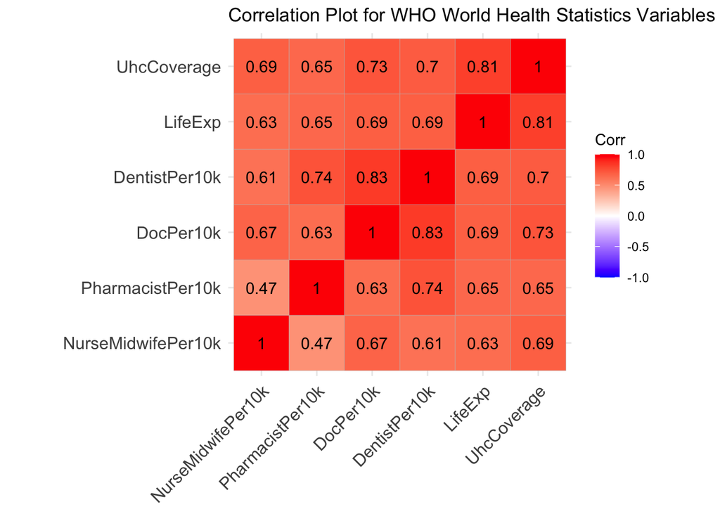

```r
# Create dataset for correlation plot
corrData <- worldHealthStat %>%
  select(c(LifeExp, DocPer10k, NurseMidwifePer10k,
           DentistPer10k, PharmacistPer10k, UhcCoverage))

# Calculate the correlation values
HealthCorr <- round(cor(corrData),2)

# Display the correlation plot
ggcorrplot(HealthCorr, hc.order = TRUE, lab = TRUE) +
  ggtitle("Correlation Plot for WHO World Health Statistics Variables")
```

The correlation plot shows that the numeric variables have strong, positive linear relationships with each other.

## Plotting Data

Several plots are created to explore the relationships within the data visually.

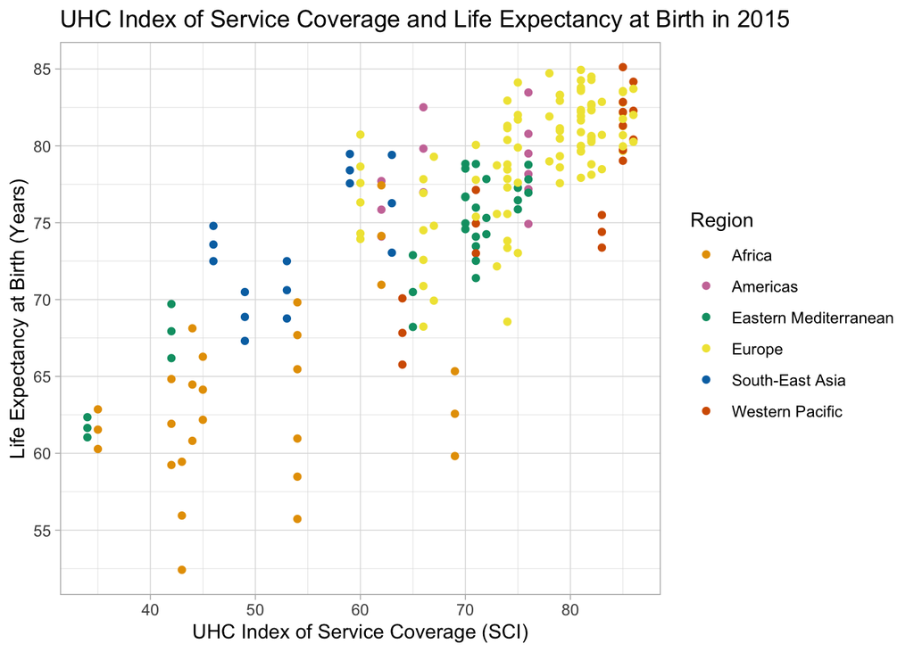

```r
# Scatterplot of life exp by uhc coverage (color coded by region)
# Hard-coded the colors in for colorblind readability
ggplot(worldHealthStat, aes(UhcCoverage, LifeExp, color=Region)) +
  geom_point() +
  xlab("UHC Index of Service Coverage (SCI)") +
  ylab("Life Expectancy at Birth (Years)") +
  ggtitle("UHC Index of Service Coverage and Life Expectancy at Birth in 2015") +
  labs(color='Region') +
  scale_y_continuous(breaks=seq(50,90,5)) +
  scale_x_continuous(breaks=seq(20,100,10)) +
  scale_color_manual(values=c("#E69F00", "#CC79A7", "#009E73", "#F0E442", "#0072B2", "#D55E00")) +
  theme_light()
```

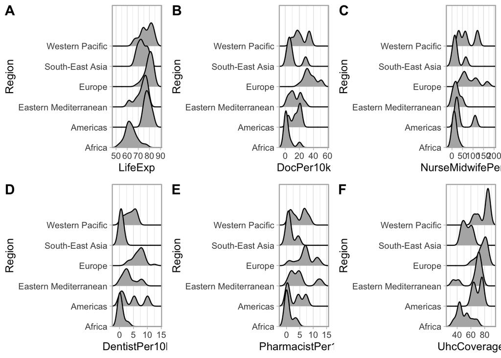

```r
# Function that creates a ggridge plot when given a dataframe, numeric X column, and categorical Y column for group
ggridgeFunction <- function(df, x, y) {

  ggplot(df, aes_string(x, y)) +
    geom_density_ridges() +
    scale_x_continuous(expand = c(0, 0)) +
    scale_y_discrete(expand = expand_scale(mult = c(0, .4))) +
    coord_cartesian(clip = "off") +
    theme_light()

}

# Creates a character vector of the numeric columns within the worldHealthStat dataframe
worldHealthStatNumericColumns <- worldHealthStat %>%
  select(-c(Location, Period, Sex, Region)) %>%
  colnames()

# Loop that cycles through the numeric column vector, creating a list of output ridgeline graphs
ridgelineOutput <- list()
for(i in worldHealthStatNumericColumns) {
  ridgelineOutput[[paste0(i,'plot')]] <- ggridgeFunction(worldHealthStat, i, 'Region')
}

# Creating the final set of ridgeline plots arranged in a 3 x 2 grid with A through F labels
plot_grid(ridgelineOutput$LifeExpplot, ridgelineOutput$DocPer10kplot, ridgelineOutput$NurseMidwifePer10kplot,
          ridgelineOutput$DentistPer10kplot, ridgelineOutput$PharmacistPer10kplot, ridgelineOutput$UhcCoverageplot,
          labels = "AUTO")
```

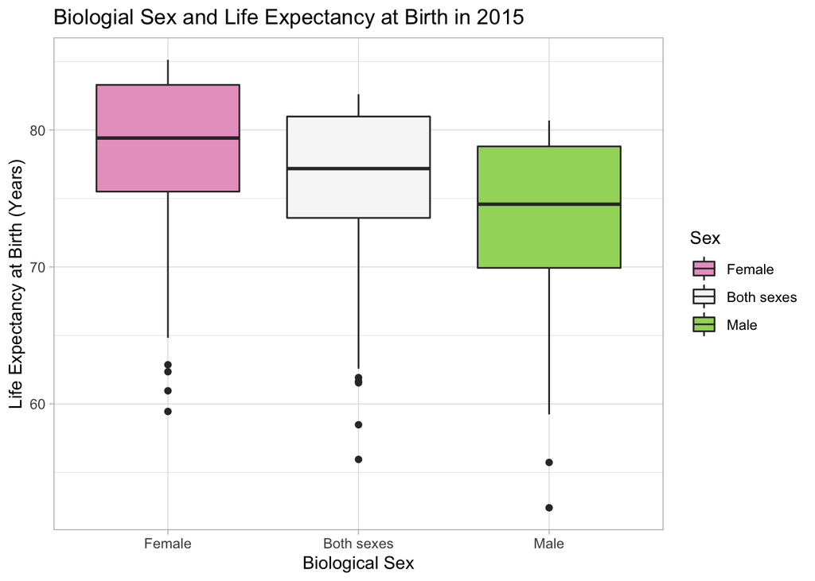

```r
# Reorder the factors in the column "Sex", so that "Both sexes" is the middle factor for the boxplot
worldHealthStat$Sex <- factor(worldHealthStat$Sex, levels = c('Female', 'Both sexes', 'Male'))

# Create boxplot of sexes by life expectancy
# PiYG is a great colorblind friendly 3-color diverging set in RColorBrewer
ggplot(worldHealthStat, aes(x = Sex, y = LifeExp, fill = Sex)) +
  geom_boxplot() +
  xlab("Biological Sex") +
  ylab("Life Expectancy at Birth (Years)") +
  ggtitle("Biologial Sex and Life Expectancy at Birth in 2015") +
  scale_fill_brewer(palette="PiYG") +
  theme_light()
```

## Regression Model

A multiple regression model is created using the data to explore how Biological Sex, Doctors Per 10k Population, Nurses/Midwives Per 10k Population, Dentists Per 10k Population, Pharmacists Per 10k Population, and UHC Coverage can predict Life Expectancy.

```r
# Remove the factor "Both sexes" from column "Sex" as it is just a calculated average between "Female" and "Male"
worldHealthStatModel <- worldHealthStat %>%
  filter(Sex == "Female" | Sex == "Male")

# Run a Multiple Linear Regression to predict Life Expectancy
modelLifeExp <- lm(LifeExp ~ Sex + DocPer10k + NurseMidwifePer10k +
             DentistPer10k + PharmacistPer10k + UhcCoverage, data = worldHealthStatModel)

# Check regression model performance
summary(modelLifeExp)
```

```
##
## Call:
## lm(formula = LifeExp ~ Sex + DocPer10k + NurseMidwifePer10k +
##     DentistPer10k + PharmacistPer10k + UhcCoverage, data = worldHealthStatModel)
##
## Residuals:
##      Min       1Q   Median       3Q      Max
## -11.0497  -1.5179   0.1916   1.6137   8.9083
##
## Coefficients:
##                     Estimate Std. Error t value Pr(>|t|)
## (Intercept)        54.964318   2.040669  26.934  < 2e-16 ***
## SexMale            -4.703846   0.603585  -7.793 2.35e-12 ***
## DocPer10k           0.034890   0.040525   0.861   0.3909
## NurseMidwifePer10k  0.010872   0.009601   1.132   0.2597
## DentistPer10k       0.223563   0.192200   1.163   0.2470
## PharmacistPer10k    0.238452   0.122181   1.952   0.0533 .
## UhcCoverage         0.279388   0.037604   7.430 1.59e-11 ***
## ---
## Signif. codes:  0 '***' 0.001 '**' 0.01 '*' 0.05 '.' 0.1 ' ' 1
##
## Residual standard error: 3.441 on 123 degrees of freedom
## Multiple R-squared:  0.7796, Adjusted R-squared:  0.7689
## F-statistic: 72.53 on 6 and 123 DF,  p-value: < 2.2e-16
```

The multiple regression model is significant and can explain 76.89% of the variance in Life Expectancy at Birth (using the Adjusted R-Squared Value). However, some of the individual predictors (Doctors Per 10k Population, Nurses/Midwives Per 10k Population, Dentists Per 10k Population, and Pharmacists Per 10k Population) were not significant in the regressor t-tests. This is likely due to there being a relationship between the predictors in this regression model. Additional exploration is needed to determine the individual impact of each predictor.

```r
# Want to check if assumptions were violated
# Check if there was any multicollinearity
vif(modelLifeExp)
```

```
##                Sex          DocPer10k NurseMidwifePer10k      DentistPer10k
##           1.000000           3.972166           2.173073           4.361215
##   PharmacistPer10k        UhcCoverage
##           2.406839           2.923852
```

The multiple regression model is based on some overall assumptions about the data used. While the Variance Inflation Factor values were below the standard cutoff of 5, based on the non-significant regressor t-tests it is likely that there is some multicollinearity between the predictors.

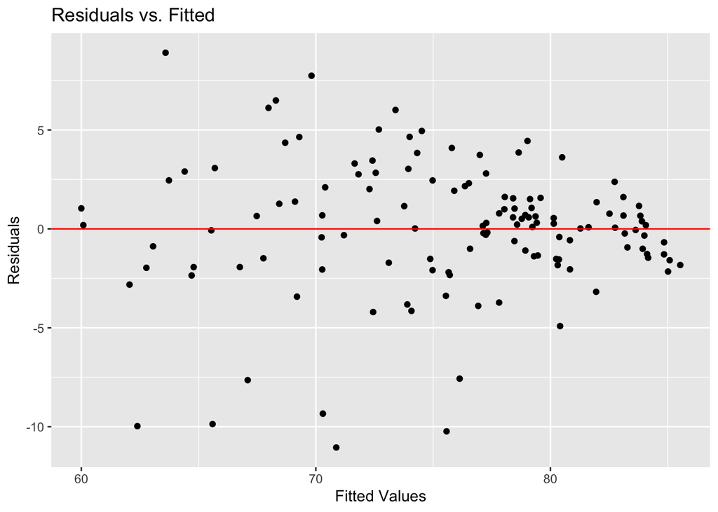

```r
# Pull out the residuals and fitted values from the model
resids<-modelLifeExp$residuals
fitvals<-modelLifeExp$fitted.values

# Residuals vs Fitted, checking assumption of linearity and homoskedasticity
ggplot() +
  geom_point(aes(fitvals,resids))+
  geom_hline(yintercept=0, col="red") +
  xlab("Fitted Values") +
  ylab("Residuals") +
  ggtitle("Residuals vs. Fitted")
```

The Residuals Vs. Fitted Values plot shows that the assumption of linearity is met, however there is some tapering on the right side which might indicate heteroskedasticity in the data and would be worth further investigation.

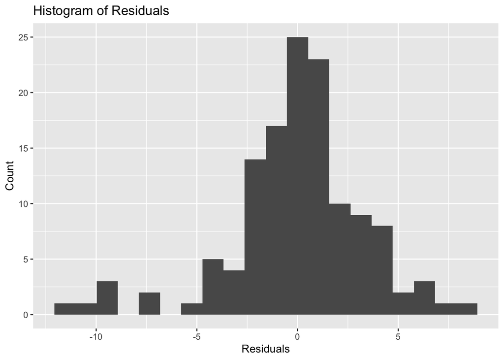

```r
# Check assumption of Normality
# Histogram
ggplot() +
  geom_histogram(aes(resids),bins=20) +
  xlab("Residuals") +
  ylab("Count") +
  ggtitle("Histogram of Residuals")
```

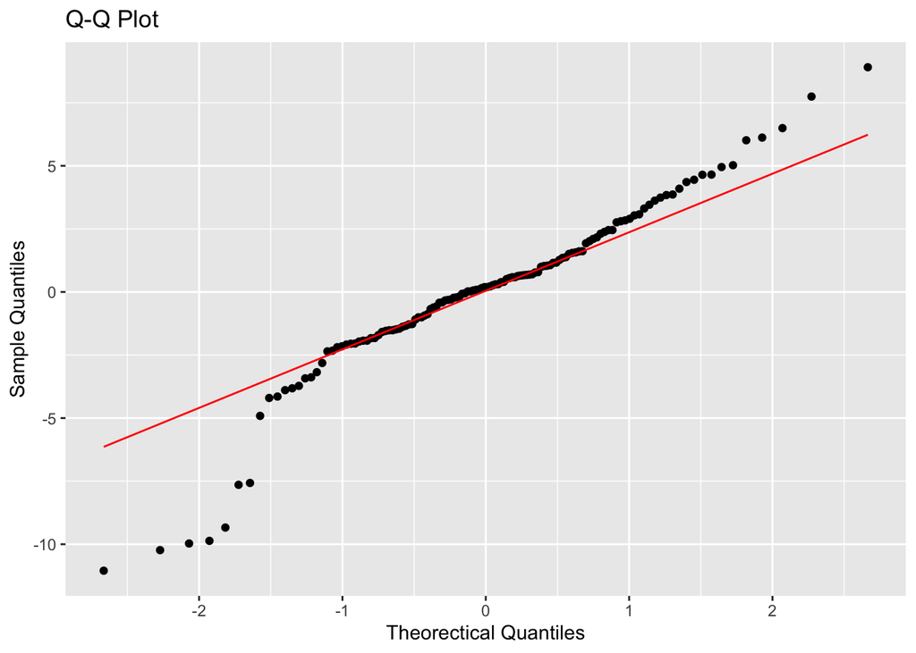

```r
# Q-Q Plot
ggplot() +
  geom_qq(aes(sample=resids)) +
  geom_qq_line(aes(sample=resids), color='red') +
  xlab("Theorectical Quantiles") +
  ylab("Sample Quantiles") +
  ggtitle("Q-Q Plot")
```

The histogram and Q-Q plot show that the assumption of normality is met in the data. The Q-Q Plot does deviate from the line on the extremes, but this can be found in normal data.